# Project: Wrangle and Analyze Data - WeRateDogs

- Data Gathering
  - Via Direct Download
  - Via Request Library
  - Via Tweepy Library
  - Reading *`tweet_json.txt`*
- Assessing Data
  - Visual Assessment
  - Programmatic Assessment
  - Quality Issues
  - Tidiness Issues
- Cleaning Data
  - Issue#1: Missing Data
  - Issue#2: Tidiness
  - Issue#3: Quality
- Storing Data
- Analyzing and Visualizing Data
  - Insights
  - Visualizations
- Data Used
- References

## Data Gathering

In the cell below, gather **all** three pieces of data for this project and load them in the notebook. **Note:** the methods required to gather each data are different.

1. Directly download the WeRateDogs Twitter archive data (twitter_archive_enhanced.csv)

*Go to Table of Contents*

```python
# Importing needed packages
import pandas as pd
import numpy as np
import matplotlib.pyplot as plt
import seaborn as sns
%matplotlib inline
import requests
import json
```

```python
# Loading manually downloaded csv file to pandas
twitter_archive = pd.read_csv('twitter-archive-enhanced.csv')
```

```python
twitter_archive
```

|  | tweet_id | in_reply_to_status_id | in_reply_to_user_id | timestamp | source | text | retweeted_status_id | retweeted_status_user_id | retweeted_status_timestamp | expanded_urls | rating_numerator | rating_denominator | name | doggo | floofer | pupper | puppo |
| --- | --- | --- | --- | --- | --- | --- | --- | --- | --- | --- | --- | --- | --- | --- | --- | --- | --- |
| 0 | 892420643555336193 | NaN | NaN | 2017-08-01 16:23:56 +0000 | <a href="http://twitter.com/download/iphone" r... | This is Phineas. He's a mystical boy. Only eve... | NaN | NaN | NaN | https://twitter.com/dog_rates/status/892420643... | 13 | 10 | Phineas | None | None | None | None |
| 1 | 892177421306343426 | NaN | NaN | 2017-08-01 00:17:27 +0000 | <a href="http://twitter.com/download/iphone" r... | This is Tilly. She's just checking pup on you.... | NaN | NaN | NaN | https://twitter.com/dog_rates/status/892177421... | 13 | 10 | Tilly | None | None | None | None |
| 2 | 891815181378084864 | NaN | NaN | 2017-07-31 00:18:03 +0000 | <a href="http://twitter.com/download/iphone" r... | This is Archie. He is a rare Norwegian Pouncin... | NaN | NaN | NaN | https://twitter.com/dog_rates/status/891815181... | 12 | 10 | Archie | None | None | None | None |
| 3 | 891689557279858688 | NaN | NaN | 2017-07-30 15:58:51 +0000 | <a href="http://twitter.com/download/iphone" r... | This is Darla. She commenced a snooze mid meal... | NaN | NaN | NaN | https://twitter.com/dog_rates/status/891689557... | 13 | 10 | Darla | None | None | None | None |
| 4 | 891327558926688256 | NaN | NaN | 2017-07-29 16:00:24 +0000 | <a href="http://twitter.com/download/iphone" r... | This is Franklin. He would like you to stop ca... | NaN | NaN | NaN | https://twitter.com/dog_rates/status/891327558... | 12 | 10 | Franklin | None | None | None | None |
| ... | ... | ... | ... | ... | ... | ... | ... | ... | ... | ... | ... | ... | ... | ... | ... | ... | ... |
| 2351 | 666049248165822465 | NaN | NaN | 2015-11-16 00:24:50 +0000 | <a href="http://twitter.com/download/iphone" r... | Here we have a 1949 1st generation vulpix. Enj... | NaN | NaN | NaN | https://twitter.com/dog_rates/status/666049248... | 5 | 10 | None | None | None | None | None |
| 2352 | 666044226329800704 | NaN | NaN | 2015-11-16 00:04:52 +0000 | <a href="http://twitter.com/download/iphone" r... | This is a purebred Piers Morgan. Loves to Netf... | NaN | NaN | NaN | https://twitter.com/dog_rates/status/666044226... | 6 | 10 | a | None | None | None | None |
| 2353 | 666033412701032449 | NaN | NaN | 2015-11-15 23:21:54 +0000 | <a href="http://twitter.com/download/iphone" r... | Here is a very happy pup. Big fan of well-main... | NaN | NaN | NaN | https://twitter.com/dog_rates/status/666033412... | 9 | 10 | a | None | None | None | None |
| 2354 | 666029285002620928 | NaN | NaN | 2015-11-15 23:05:30 +0000 | <a href="http://twitter.com/download/iphone" r... | This is a western brown Mitsubishi terrier. Up... | NaN | NaN | NaN | https://twitter.com/dog_rates/status/666029285... | 7 | 10 | a | None | None | None | None |
| 2355 | 666020888022790149 | NaN | NaN | 2015-11-15 22:32:08 +0000 | <a href="http://twitter.com/download/iphone" r... | Here we have a Japanese Irish Setter. Lost eye... | NaN | NaN | NaN | https://twitter.com/dog_rates/status/666020888... | 8 | 10 | None | None | None | None | None |

2356 rows × 17 columns

1. Use the Requests library to download the tweet image prediction (image_predictions.tsv)

```python
# Programmatically downloading the image prediction file with url provided using requests
image_prediction_url = 'https://d17h27t6h515a5.cloudfront.net/topher/2017/August/599fd2ad_image-predictions/image-predictions.tsv'
response = requests.get(image_prediction_url)
response
```

```
<Response [200]>
```

```python
# Checking raw file which is in bytes
response.content
```

```
b"tweet_id\tjpg_url\timg_num\tp1\tp1_conf\tp1_dog\tp2\tp2_conf\tp2_dog\tp3\tp3_conf\tp3_dog\n666020888022790149\thttps://pbs.twimg.com/media/CT4udn0WwAA0aMy.jpg\t1\tWelsh_springer_spaniel\t0.465074\tTrue\tcollie\t0.156665\tTrue\tShetland_sheepdog\t0.0614285\tTrue\n666029285002620928\thttps://pbs.twi…
```

```python
len(response.content)
```

```
335079
```

```python
# Opening and saving file to computer
with open (image_prediction_url.split('/')[-1], mode='wb') as file:
    file.write(response.content)
```

```python
# Loading the file to pandas
image_predictions = pd.read_csv('image-predictions.tsv', sep='\t')
```

```python
image_predictions
```

|  | tweet_id | jpg_url | img_num | p1 | p1_conf | p1_dog | p2 | p2_conf | p2_dog | p3 | p3_conf | p3_dog |
| --- | --- | --- | --- | --- | --- | --- | --- | --- | --- | --- | --- | --- |
| 0 | 666020888022790149 | https://pbs.twimg.com/media/CT4udn0WwAA0aMy.jpg | 1 | Welsh_springer_spaniel | 0.465074 | True | collie | 0.156665 | True | Shetland_sheepdog | 0.061428 | True |
| 1 | 666029285002620928 | https://pbs.twimg.com/media/CT42GRgUYAA5iDo.jpg | 1 | redbone | 0.506826 | True | miniature_pinscher | 0.074192 | True | Rhodesian_ridgeback | 0.072010 | True |
| 2 | 666033412701032449 | https://pbs.twimg.com/media/CT4521TWwAEvMyu.jpg | 1 | German_shepherd | 0.596461 | True | malinois | 0.138584 | True | bloodhound | 0.116197 | True |
| 3 | 666044226329800704 | https://pbs.twimg.com/media/CT5Dr8HUEAA-lEu.jpg | 1 | Rhodesian_ridgeback | 0.408143 | True | redbone | 0.360687 | True | miniature_pinscher | 0.222752 | True |
| 4 | 666049248165822465 | https://pbs.twimg.com/media/CT5IQmsXIAAKY4A.jpg | 1 | miniature_pinscher | 0.560311 | True | Rottweiler | 0.243682 | True | Doberman | 0.154629 | True |
| ... | ... | ... | ... | ... | ... | ... | ... | ... | ... | ... | ... | ... |
| 2070 | 891327558926688256 | https://pbs.twimg.com/media/DF6hr6BUMAAzZgT.jpg | 2 | basset | 0.555712 | True | English_springer | 0.225770 | True | German_short-haired_pointer | 0.175219 | True |
| 2071 | 891689557279858688 | https://pbs.twimg.com/media/DF_q7IAWsAEuuN8.jpg | 1 | paper_towel | 0.170278 | False | Labrador_retriever | 0.168086 | True | spatula | 0.040836 | False |
| 2072 | 891815181378084864 | https://pbs.twimg.com/media/DGBdLU1WsAANxJ9.jpg | 1 | Chihuahua | 0.716012 | True | malamute | 0.078253 | True | kelpie | 0.031379 | True |
| 2073 | 892177421306343426 | https://pbs.twimg.com/media/DGGmoV4XsAAUL6n.jpg | 1 | Chihuahua | 0.323581 | True | Pekinese | 0.090647 | True | papillon | 0.068957 | True |
| 2074 | 892420643555336193 | https://pbs.twimg.com/media/DGKD1-bXoAAIAUK.jpg | 1 | orange | 0.097049 | False | bagel | 0.085851 | False | banana | 0.076110 | False |

2075 rows × 12 columns

*Go to Table of Contents*

1. Use the Tweepy library to query additional data via the Twitter API (tweet_json.txt)

```python
# From student: Do not run because it returns "fail" for all ids as API access is not yet authenticated
import tweepy
from tweepy import OAuthHandler
import json
from timeit import default_timer as timer

# Query Twitter API for each tweet in the Twitter archive and save JSON in a text file
# These are hidden to comply with Twitter's API terms and conditions
consumer_key = 'HIDDEN'
consumer_secret = 'HIDDEN'
access_token = 'HIDDEN'
access_secret = 'HIDDEN'

auth = OAuthHandler(consumer_key, consumer_secret)
auth.set_access_token(access_token, access_secret)

api = tweepy.API(auth, wait_on_rate_limit=True)

# NOTE TO STUDENT WITH MOBILE VERIFICATION ISSUES:
# df_1 is a DataFrame with the twitter_archive_enhanced.csv file. You may have to
# change line 17 to match the name of your DataFrame with twitter_archive_enhanced.csv
# NOTE TO REVIEWER: this student had mobile verification issues so the following
# Twitter API code was sent to this student from a Udacity instructor
# Tweet IDs for which to gather additional data via Twitter's API

tweet_ids = df_1.tweet_id.values # From student: use twitter_archive inplace of df_1
len(tweet_ids)

# Query Twitter's API for JSON data for each tweet ID in the Twitter archive
count = 0
fails_dict = {}
start = timer()
# Save each tweet's returned JSON as a new line in a .txt file
with open('tweet_json.txt', 'w') as outfile:
    # This loop will likely take 20-30 minutes to run because of Twitter's rate limit
    for tweet_id in tweet_ids:
        count += 1
        print(str(count) + ": " + str(tweet_id))
        try:
            tweet = api.get_status(tweet_id, tweet_mode='extended')
            print("Success")
            json.dump(tweet._json, outfile)
            outfile.write('\n')
        except tweepy.TweepError as e: # From student: use tweepy.TweepyException
            print("Fail")
            fails_dict[tweet_id] = e
            pass
end = timer()
print(end - start)
print(fails_dict)
```

*Go to Table of Contents*

Reading tweet_json.txt file line by line into a pandas DataFrame with (at minimum) tweet ID, retweet count, and favorite count.

```python
# Creating empty list to append dictionaries and convert to DataFrame later
tweets_list = []
# Reading tweet_json.txt file line by line
with open ('tweet-json.txt', 'r') as json_txt:
    for line in json_txt:
        dict_data = json.loads(line)
        # Appending to list
        tweets_list.append(dict_data)
        #print(dict_data)        #prints dictionary data for one tweet
        #break
# Converting to a pandas DataFrame
json_tweets = pd.DataFrame(tweets_list, columns=['id', 'retweet_count', 'favorite_count'])
```

```python
json_tweets
```

|  | id | retweet_count | favorite_count |
| --- | --- | --- | --- |
| 0 | 892420643555336193 | 8853 | 39467 |
| 1 | 892177421306343426 | 6514 | 33819 |
| 2 | 891815181378084864 | 4328 | 25461 |
| 3 | 891689557279858688 | 8964 | 42908 |
| 4 | 891327558926688256 | 9774 | 41048 |
| ... | ... | ... | ... |
| 2349 | 666049248165822465 | 41 | 111 |
| 2350 | 666044226329800704 | 147 | 311 |
| 2351 | 666033412701032449 | 47 | 128 |
| 2352 | 666029285002620928 | 48 | 132 |
| 2353 | 666020888022790149 | 532 | 2535 |

2354 rows × 3 columns

*Go to Table of Contents*

## Assessing Data

In this section, detect and document at least **eight (8) quality issues and two (2) tidiness issue**. You must use **both** visual assessment programmatic assessement to assess the data.

**Note:** pay attention to the following key points when you access the data.

- You only want original ratings (no retweets) that have images. Though there are 5000+ tweets in the dataset, not all are dog ratings and some are retweets.
- Assessing and cleaning the entire dataset completely would require a lot of time, and is not necessary to practice and demonstrate your skills in data wrangling. Therefore, the requirements of this project are only to assess and clean at least 8 quality issues and at least 2 tidiness issues in this dataset.
- The fact that the rating numerators are greater than the denominators does not need to be cleaned. This [unique rating system](http://knowyourmeme.com/memes/theyre-good-dogs-brent) is a big part of the popularity of WeRateDogs.
- You do not need to gather the tweets beyond August 1st, 2017. You can, but note that you won't be able to gather the image predictions for these tweets since you don't have access to the algorithm used.

#### Datasets to be assessed:

- `twitter_archive`
- `image_predictions`
- `json_tweets`

*Go to Table of Contents*

#### Visual Assessment of tables

```python
# Displaying the twitter_archive table
twitter_archive
```

|  | tweet_id | in_reply_to_status_id | in_reply_to_user_id | timestamp | source | text | retweeted_status_id | retweeted_status_user_id | retweeted_status_timestamp | expanded_urls | rating_numerator | rating_denominator | name | doggo | floofer | pupper | puppo |
| --- | --- | --- | --- | --- | --- | --- | --- | --- | --- | --- | --- | --- | --- | --- | --- | --- | --- |
| 0 | 892420643555336193 | NaN | NaN | 2017-08-01 16:23:56 +0000 | <a href="http://twitter.com/download/iphone" r... | This is Phineas. He's a mystical boy. Only eve... | NaN | NaN | NaN | https://twitter.com/dog_rates/status/892420643... | 13 | 10 | Phineas | None | None | None | None |
| 1 | 892177421306343426 | NaN | NaN | 2017-08-01 00:17:27 +0000 | <a href="http://twitter.com/download/iphone" r... | This is Tilly. She's just checking pup on you.... | NaN | NaN | NaN | https://twitter.com/dog_rates/status/892177421... | 13 | 10 | Tilly | None | None | None | None |
| 2 | 891815181378084864 | NaN | NaN | 2017-07-31 00:18:03 +0000 | <a href="http://twitter.com/download/iphone" r... | This is Archie. He is a rare Norwegian Pouncin... | NaN | NaN | NaN | https://twitter.com/dog_rates/status/891815181... | 12 | 10 | Archie | None | None | None | None |
| 3 | 891689557279858688 | NaN | NaN | 2017-07-30 15:58:51 +0000 | <a href="http://twitter.com/download/iphone" r... | This is Darla. She commenced a snooze mid meal... | NaN | NaN | NaN | https://twitter.com/dog_rates/status/891689557... | 13 | 10 | Darla | None | None | None | None |
| 4 | 891327558926688256 | NaN | NaN | 2017-07-29 16:00:24 +0000 | <a href="http://twitter.com/download/iphone" r... | This is Franklin. He would like you to stop ca... | NaN | NaN | NaN | https://twitter.com/dog_rates/status/891327558... | 12 | 10 | Franklin | None | None | None | None |
| ... | ... | ... | ... | ... | ... | ... | ... | ... | ... | ... | ... | ... | ... | ... | ... | ... | ... |
| 2351 | 666049248165822465 | NaN | NaN | 2015-11-16 00:24:50 +0000 | <a href="http://twitter.com/download/iphone" r... | Here we have a 1949 1st generation vulpix. Enj... | NaN | NaN | NaN | https://twitter.com/dog_rates/status/666049248... | 5 | 10 | None | None | None | None | None |
| 2352 | 666044226329800704 | NaN | NaN | 2015-11-16 00:04:52 +0000 | <a href="http://twitter.com/download/iphone" r... | This is a purebred Piers Morgan. Loves to Netf... | NaN | NaN | NaN | https://twitter.com/dog_rates/status/666044226... | 6 | 10 | a | None | None | None | None |
| 2353 | 666033412701032449 | NaN | NaN | 2015-11-15 23:21:54 +0000 | <a href="http://twitter.com/download/iphone" r... | Here is a very happy pup. Big fan of well-main... | NaN | NaN | NaN | https://twitter.com/dog_rates/status/666033412... | 9 | 10 | a | None | None | None | None |
| 2354 | 666029285002620928 | NaN | NaN | 2015-11-15 23:05:30 +0000 | <a href="http://twitter.com/download/iphone" r... | This is a western brown Mitsubishi terrier. Up... | NaN | NaN | NaN | https://twitter.com/dog_rates/status/666029285... | 7 | 10 | a | None | None | None | None |
| 2355 | 666020888022790149 | NaN | NaN | 2015-11-15 22:32:08 +0000 | <a href="http://twitter.com/download/iphone" r... | Here we have a Japanese Irish Setter. Lost eye... | NaN | NaN | NaN | https://twitter.com/dog_rates/status/666020888... | 8 | 10 | None | None | None | None | None |

2356 rows × 17 columns

`twitter_archive` columns:

- **tweet_id:** The unique identifier for this Tweet.
- **in_reply_to_status_id:** If the represented Tweet is a reply, this field will contain the representation of the original Tweet’s ID. Nullable
- **in_reply_to_user_id:** If the represented Tweet is a reply, this field will contain the representation of the original Tweet’s author ID. This will not necessarily always be the user directly mentioned in the Tweet. Nullable
- **timestamp:** UTC time when this Tweet was created.
- **source:** Utility used to post the Tweet, as an HTML-formatted string. Tweets from the Twitter website have a source value of web.
- **text:** The actual UTF-8 text of the status update.
- **retweeted_status_id:** The representation of the original Tweet’s ID if the represented Tweet is a Retweet.
- **retweeted_status_user_id:** The representation of the original Tweet’s author ID if the represented Tweet is a Retweet.
- **retweeted_status_timestamp:** UTC time when this Retweet was created.
- **expanded_urls:** full url of Tweet.
- **rating_numerator:** The numerator rating of the dogs. They are almost always greater than 10. (eg.11/10, 12/10, 13/10, etc) because "[they're good dogs Brent](http://knowyourmeme.com/memes/theyre-good-dogs-brent)".
- **rating_denominator:** The denominator ratings of the dogs. They almost always have a denominator of 10.
- **name:** The name of the dog.
- **doggo:** One of the various dog stages as explained by the Dogtionary via [#WeRateDogs book](https://www.amazon.com/WeRateDogs-Most-Hilarious-Adorable-Youve/dp/1510717145) on Amazon
- **floofer:** One of the various dog stages as explained above
- **pupper:** One of the various dog stages as explained above
- **puppo:** One of the various dog stages as explained above

Some columns listed above are explained further in the [Tweet Data Dictionary](https://developer.twitter.com/en/docs/twitter-api/v1/data-dictionary/object-model/tweet)

```python
# Displaying the image_predictions table
image_predictions
```

|  | tweet_id | jpg_url | img_num | p1 | p1_conf | p1_dog | p2 | p2_conf | p2_dog | p3 | p3_conf | p3_dog |
| --- | --- | --- | --- | --- | --- | --- | --- | --- | --- | --- | --- | --- |
| 0 | 666020888022790149 | https://pbs.twimg.com/media/CT4udn0WwAA0aMy.jpg | 1 | Welsh_springer_spaniel | 0.465074 | True | collie | 0.156665 | True | Shetland_sheepdog | 0.061428 | True |
| 1 | 666029285002620928 | https://pbs.twimg.com/media/CT42GRgUYAA5iDo.jpg | 1 | redbone | 0.506826 | True | miniature_pinscher | 0.074192 | True | Rhodesian_ridgeback | 0.072010 | True |
| 2 | 666033412701032449 | https://pbs.twimg.com/media/CT4521TWwAEvMyu.jpg | 1 | German_shepherd | 0.596461 | True | malinois | 0.138584 | True | bloodhound | 0.116197 | True |
| 3 | 666044226329800704 | https://pbs.twimg.com/media/CT5Dr8HUEAA-lEu.jpg | 1 | Rhodesian_ridgeback | 0.408143 | True | redbone | 0.360687 | True | miniature_pinscher | 0.222752 | True |
| 4 | 666049248165822465 | https://pbs.twimg.com/media/CT5IQmsXIAAKY4A.jpg | 1 | miniature_pinscher | 0.560311 | True | Rottweiler | 0.243682 | True | Doberman | 0.154629 | True |
| ... | ... | ... | ... | ... | ... | ... | ... | ... | ... | ... | ... | ... |
| 2070 | 891327558926688256 | https://pbs.twimg.com/media/DF6hr6BUMAAzZgT.jpg | 2 | basset | 0.555712 | True | English_springer | 0.225770 | True | German_short-haired_pointer | 0.175219 | True |
| 2071 | 891689557279858688 | https://pbs.twimg.com/media/DF_q7IAWsAEuuN8.jpg | 1 | paper_towel | 0.170278 | False | Labrador_retriever | 0.168086 | True | spatula | 0.040836 | False |
| 2072 | 891815181378084864 | https://pbs.twimg.com/media/DGBdLU1WsAANxJ9.jpg | 1 | Chihuahua | 0.716012 | True | malamute | 0.078253 | True | kelpie | 0.031379 | True |
| 2073 | 892177421306343426 | https://pbs.twimg.com/media/DGGmoV4XsAAUL6n.jpg | 1 | Chihuahua | 0.323581 | True | Pekinese | 0.090647 | True | papillon | 0.068957 | True |
| 2074 | 892420643555336193 | https://pbs.twimg.com/media/DGKD1-bXoAAIAUK.jpg | 1 | orange | 0.097049 | False | bagel | 0.085851 | False | banana | 0.076110 | False |

2075 rows × 12 columns

`image_predictions` columns:

- **tweet_id:** The unique identifier for this Tweet.
- **jpg_url:** The image URL
- **img_num:** The image number that corresponds to the most confident prediction (numbered 1 to 4 since tweets can have up to four images).
- **p1:** The algorithm's #1 prediction for the image in the tweet
- **p1_conf:** How confident the algorithm is in its #1 prediction in %
- **p1_dog:** Whether or not the #1 prediction is a breed of dog
- **p2:** The algorithm's 2nd most likely prediction
- **p2_conf:** How confident the algorithm is in its #2 prediction in %
- **p2_dog:** Whether or not the #2 prediction is a breed of dog
- **p3:** The algorithm's 3rd most likely prediction
- **p3_conf:** How confident the algorithm is in its #3 prediction in %
- **p3_dog:** Whether or not the #2 prediction is a breed of dog

```python
# Displaying the json_tweets table
json_tweets
```

|  | id | retweet_count | favorite_count |
| --- | --- | --- | --- |
| 0 | 892420643555336193 | 8853 | 39467 |
| 1 | 892177421306343426 | 6514 | 33819 |
| 2 | 891815181378084864 | 4328 | 25461 |
| 3 | 891689557279858688 | 8964 | 42908 |
| 4 | 891327558926688256 | 9774 | 41048 |
| ... | ... | ... | ... |
| 2349 | 666049248165822465 | 41 | 111 |
| 2350 | 666044226329800704 | 147 | 311 |
| 2351 | 666033412701032449 | 47 | 128 |
| 2352 | 666029285002620928 | 48 | 132 |
| 2353 | 666020888022790149 | 532 | 2535 |

2354 rows × 3 columns

`json_tweets` columns:

- **id:** The unique identifier for this Tweet
- **retweet_count:** Count of the times this Tweet has been Retweeted by the authenticating user
- **favorite_count:** Count of the times this Tweet has been liked or "favorited" by the authenticating user

*Go to Table of Contents*

#### Programmatic Assessment of tables

Assessing the *`twitter_archive`* table

```python
twitter_archive.info()
```

```
<class 'pandas.core.frame.DataFrame'>
RangeIndex: 2356 entries, 0 to 2355
Data columns (total 17 columns):
 #   Column                      Non-Null Count  Dtype
---  ------                      --------------  -----
 0   tweet_id                    2356 non-null   int64
 1   in_reply_to_status_id       78 non-null     float64
 2   in_reply_to_user_id         78 non-null     float64
 3   timestamp                   2356 non-null   object
 4   source                      2356 non-null   object
 5   text                        2356 non-null   object
 6   retweeted_status_id         181 non-null    float64
 7   retweeted_status_user_id    181 non-null    float64
 8   retweeted_status_timestamp  181 non-null    object
 9   expanded_urls               2297 non-null   object
 10  rating_numerator            2356 non-null   int64
 11  rating_denominator          2356 non-null   int64
 12  name                        2356 non-null   object
 13  doggo                       2356 non-null   object
 14  floofer                     2356 non-null   object
 15  pupper                      2356 non-null   object
 16  puppo                       2356 non-null   object
dtypes: float64(4), int64(3), object(10)
memory usage: 313.0+ KB
```

```python
twitter_archive.sample(10)
```

|  | tweet_id | in_reply_to_status_id | in_reply_to_user_id | timestamp | source | text | retweeted_status_id | retweeted_status_user_id | retweeted_status_timestamp | expanded_urls | rating_numerator | rating_denominator | name | doggo | floofer | pupper | puppo |
| --- | --- | --- | --- | --- | --- | --- | --- | --- | --- | --- | --- | --- | --- | --- | --- | --- | --- |
| 1838 | 675898130735476737 | NaN | NaN | 2015-12-13 04:40:46 +0000 | <a href="http://twitter.com/download/iphone" r... | I'm sure you've all seen this pupper. Not prep... | NaN | NaN | NaN | https://twitter.com/dog_rates/status/675898130... | 10 | 10 | None | None | None | pupper | None |
| 333 | 832757312314028032 | NaN | NaN | 2017-02-18 01:03:09 +0000 | <a href="http://twitter.com/download/iphone" r... | This is Willow. She's the official strawberry ... | NaN | NaN | NaN | https://twitter.com/dog_rates/status/832757312... | 13 | 10 | Willow | None | None | None | None |
| 128 | 867774946302451713 | NaN | NaN | 2017-05-25 16:10:44 +0000 | <a href="http://twitter.com/download/iphone" r... | Meet Harold. He's h*ckin cooperative. 13/10 g... | NaN | NaN | NaN | https://twitter.com/dog_rates/status/867774946... | 13 | 10 | Harold | None | None | None | None |
| 1560 | 688519176466644993 | NaN | NaN | 2016-01-17 00:32:18 +0000 | <a href="http://twitter.com/download/iphone" r... | This pupper is sprouting a flower out of her h... | NaN | NaN | NaN | https://twitter.com/dog_rates/status/688519176... | 12 | 10 | None | None | None | pupper | None |
| 818 | 770743923962707968 | NaN | NaN | 2016-08-30 22:04:05 +0000 | <a href="http://twitter.com/download/iphone" r... | RT @dog_rates: Here's a doggo blowing bubbles.... | 7.392382e+17 | 4.196984e+09 | 2016-06-04 23:31:25 +0000 | https://twitter.com/dog_rates/status/739238157... | 13 | 10 | None | doggo | None | None | None |
| 1897 | 674737130913071104 | NaN | NaN | 2015-12-09 23:47:22 +0000 | <a href="http://twitter.com/download/iphone" r... | Meet Rufio. He is unaware of the pink legless ... | NaN | NaN | NaN | https://twitter.com/dog_rates/status/674737130... | 10 | 10 | Rufio | None | None | pupper | None |
| 387 | 826598799820865537 | 8.265984e+17 | 4.196984e+09 | 2017-02-01 01:11:25 +0000 | <a href="http://twitter.com/download/iphone" r... | I was going to do 007/10, but the joke wasn't ... | NaN | NaN | NaN | NaN | 7 | 10 | None | None | None | None | None |
| 1179 | 719367763014393856 | NaN | NaN | 2016-04-11 03:33:34 +0000 | <a href="http://twitter.com/download/iphone" r... | Meet Sid &amp; Murphy. Murphy floats alongside... | NaN | NaN | NaN | https://twitter.com/dog_rates/status/719367763... | 11 | 10 | Sid | None | None | None | None |
| 1226 | 713919462244790272 | NaN | NaN | 2016-03-27 02:43:58 +0000 | <a href="http://twitter.com/download/iphone" r... | This is Kanu. He's a Freckled Ticonderoga. Sim... | NaN | NaN | NaN | https://twitter.com/dog_rates/status/713919462... | 12 | 10 | Kanu | None | None | None | None |
| 210 | 852189679701164033 | NaN | NaN | 2017-04-12 16:00:27 +0000 | <a href="http://twitter.com/download/iphone" r... | This is Sailor. He has collected the best dirt... | NaN | NaN | NaN | https://twitter.com/dog_rates/status/852189679... | 12 | 10 | Sailor | None | None | None | None |

```python
list(twitter_archive)
```

```
['tweet_id',
 'in_reply_to_status_id',
 'in_reply_to_user_id',
 'timestamp',
 'source',
 'text',
 'retweeted_status_id',
 'retweeted_status_user_id',
 'retweeted_status_timestamp',
 'expanded_urls',
 'rating_numerator',
 'rating_denominator',
 'name',
 'doggo',
 'floofer',
 'pupper',
 'puppo']
```

```python
twitter_archive.name.value_counts()
```

```
None          745
a              55
Charlie        12
Cooper         11
Lucy           11
             ...
Dex             1
Ace             1
Tayzie          1
Grizzie         1
Christoper      1
Name: name, Length: 957, dtype: int64
```

```python
sum(twitter_archive['name'].isnull())
```

```
0
```

```python
twitter_archive.describe()
```

|  | tweet_id | in_reply_to_status_id | in_reply_to_user_id | retweeted_status_id | retweeted_status_user_id | rating_numerator | rating_denominator |
| --- | --- | --- | --- | --- | --- | --- | --- |
| count | 2.356000e+03 | 7.800000e+01 | 7.800000e+01 | 1.810000e+02 | 1.810000e+02 | 2356.000000 | 2356.000000 |
| mean | 7.427716e+17 | 7.455079e+17 | 2.014171e+16 | 7.720400e+17 | 1.241698e+16 | 13.126486 | 10.455433 |
| std | 6.856705e+16 | 7.582492e+16 | 1.252797e+17 | 6.236928e+16 | 9.599254e+16 | 45.876648 | 6.745237 |
| min | 6.660209e+17 | 6.658147e+17 | 1.185634e+07 | 6.661041e+17 | 7.832140e+05 | 0.000000 | 0.000000 |
| 25% | 6.783989e+17 | 6.757419e+17 | 3.086374e+08 | 7.186315e+17 | 4.196984e+09 | 10.000000 | 10.000000 |
| 50% | 7.196279e+17 | 7.038708e+17 | 4.196984e+09 | 7.804657e+17 | 4.196984e+09 | 11.000000 | 10.000000 |
| 75% | 7.993373e+17 | 8.257804e+17 | 4.196984e+09 | 8.203146e+17 | 4.196984e+09 | 12.000000 | 10.000000 |
| max | 8.924206e+17 | 8.862664e+17 | 8.405479e+17 | 8.874740e+17 | 7.874618e+17 | 1776.000000 | 170.000000 |

Assessing the *`image_predictions`* table

```python
list(image_predictions)
```

```
['tweet_id',
 'jpg_url',
 'img_num',
 'p1',
 'p1_conf',
 'p1_dog',
 'p2',
 'p2_conf',
 'p2_dog',
 'p3',
 'p3_conf',
 'p3_dog']
```

```python
image_predictions.info()
```

```
<class 'pandas.core.frame.DataFrame'>
RangeIndex: 2075 entries, 0 to 2074
Data columns (total 12 columns):
 #   Column    Non-Null Count  Dtype
---  ------    --------------  -----
 0   tweet_id  2075 non-null   int64
 1   jpg_url   2075 non-null   object
 2   img_num   2075 non-null   int64
 3   p1        2075 non-null   object
 4   p1_conf   2075 non-null   float64
 5   p1_dog    2075 non-null   bool
 6   p2        2075 non-null   object
 7   p2_conf   2075 non-null   float64
 8   p2_dog    2075 non-null   bool
 9   p3        2075 non-null   object
 10  p3_conf   2075 non-null   float64
 11  p3_dog    2075 non-null   bool
dtypes: bool(3), float64(3), int64(2), object(4)
memory usage: 152.1+ KB
```

```python
image_predictions.sample(5)
```

|  | tweet_id | jpg_url | img_num | p1 | p1_conf | p1_dog | p2 | p2_conf | p2_dog | p3 | p3_conf | p3_dog |
| --- | --- | --- | --- | --- | --- | --- | --- | --- | --- | --- | --- | --- |
| 14 | 666094000022159362 | https://pbs.twimg.com/media/CT5w9gUW4AAsBNN.jpg | 1 | bloodhound | 0.195217 | True | German_shepherd | 0.078260 | True | malinois | 0.075628 | True |
| 1735 | 821765923262631936 | https://pbs.twimg.com/media/C2d_vnHWEAE9phX.jpg | 1 | golden_retriever | 0.980071 | True | Labrador_retriever | 0.008758 | True | Saluki | 0.001806 | True |
| 120 | 668190681446379520 | https://pbs.twimg.com/media/CUXj4SgXAAETlu6.jpg | 1 | Blenheim_spaniel | 0.958402 | True | cocker_spaniel | 0.026764 | True | Welsh_springer_spaniel | 0.007790 | True |
| 1282 | 750383411068534784 | https://pbs.twimg.com/media/CmnluwbXEAAqnkw.jpg | 1 | Border_collie | 0.672791 | True | collie | 0.270188 | True | papillon | 0.034504 | True |
| 1638 | 806629075125202948 | https://pbs.twimg.com/media/CzG425nWgAAnP7P.jpg | 2 | Arabian_camel | 0.366248 | False | house_finch | 0.209852 | False | cocker_spaniel | 0.046403 | True |

```python
sum(image_predictions.duplicated())
```

```
0
```

```python
image_predictions.describe()
```

|  | tweet_id | img_num | p1_conf | p2_conf | p3_conf |
| --- | --- | --- | --- | --- | --- |
| count | 2.075000e+03 | 2075.000000 | 2075.000000 | 2.075000e+03 | 2.075000e+03 |
| mean | 7.384514e+17 | 1.203855 | 0.594548 | 1.345886e-01 | 6.032417e-02 |
| std | 6.785203e+16 | 0.561875 | 0.271174 | 1.006657e-01 | 5.090593e-02 |
| min | 6.660209e+17 | 1.000000 | 0.044333 | 1.011300e-08 | 1.740170e-10 |
| 25% | 6.764835e+17 | 1.000000 | 0.364412 | 5.388625e-02 | 1.622240e-02 |
| 50% | 7.119988e+17 | 1.000000 | 0.588230 | 1.181810e-01 | 4.944380e-02 |
| 75% | 7.932034e+17 | 1.000000 | 0.843855 | 1.955655e-01 | 9.180755e-02 |
| max | 8.924206e+17 | 4.000000 | 1.000000 | 4.880140e-01 | 2.734190e-01 |

Assessing the *`json_tweets`* table

```python
list(json_tweets)
```

```
['id', 'retweet_count', 'favorite_count']
```

```python
json_tweets.info()
```

```
<class 'pandas.core.frame.DataFrame'>
RangeIndex: 2354 entries, 0 to 2353
Data columns (total 3 columns):
 #   Column          Non-Null Count  Dtype
---  ------          --------------  -----
 0   id              2354 non-null   int64
 1   retweet_count   2354 non-null   int64
 2   favorite_count  2354 non-null   int64
dtypes: int64(3)
memory usage: 55.3 KB
```

```python
json_tweets.sample(5)
```

|  | id | retweet_count | favorite_count |
| --- | --- | --- | --- |
| 703 | 785872687017132033 | 2130 | 7489 |
| 1729 | 679844490799091713 | 887 | 2593 |
| 2014 | 672169685991993344 | 408 | 1074 |
| 1302 | 707411934438625280 | 673 | 2486 |
| 1094 | 736365877722001409 | 1408 | 4367 |

- The three tables combined

```python
# Checking for duplicated columns in the the three tables
total_columns = pd.Series(list(twitter_archive) + list(image_predictions) + list(json_tweets))
total_columns[total_columns.duplicated()]
```

```
17    tweet_id
dtype: object
```

*Go to Table of Contents*

### Quality issues

*`twitter_archive` table:*

1. Missing values in 6 columns (*in_reply_to_status_id*, *in_reply_to_user_id*, *retweeted_status_id*, *retweeted_status_user_id*, *retweeted_status_timestamp* and *expanded_urls*) .
2. Erroneous `timestamp` datatype (should be datetime and not object).
3. "None" and lower case strings such as "a", "such", "the" etc used to represent dogs with no names.

*`image_predictions` table:*

1. In the `p1`, `p2` and `p3` columns, some names start with uppercase letters while some start with lowercase letters.
2. Duplicate `tweet_id` column.

*`json_tweets` table:*

1. Incorrect column name: `id` column represented as "id" instead of "tweet_id".
2. Duplicate `tweet_id` column.

*General to the three tables*

1. Erroneous `tweet_id`/`id` datatype (should be represented as *string/object* and not *int* for safety purposes according to [Tweet Data Dictionary](https://developer.twitter.com/en/docs/twitter-api/v1/data-dictionary/object-model/tweet) ).

### Tidiness issues

1. One variable (dog_stage) in four columns in the `twitter_archive` table.
2. *tweet_id* column in `twitter_archive` table duplicated in `image_predictions` table and in `json_tweets` table as 'id'. 3.`json_tweets` table should be part of the `twitter_archive` table.

*Go to Table of Contents*

## Cleaning Data

In this section, clean **all** of the issues you documented while assessing.

**Note:** Make a copy of the original data before cleaning. Cleaning includes merging individual pieces of data according to the rules of [tidy data](https://cran.r-project.org/web/packages/tidyr/vignettes/tidy-data.html). The result should be a high-quality and tidy master pandas DataFrame (or DataFrames, if appropriate).

```python
# Make copies of original pieces of data
twitter_archive_clean = twitter_archive.copy()
image_predictions_clean = image_predictions.copy()
json_tweets_clean = json_tweets.copy()
```

*Go to Table of Contents*

### Issue #1: Missing Data

**`twitter_archive`** table:

**Missing values in 6 columns (*in_reply_to_status_id*, *in_reply_to_user_id*, *retweeted_status_id*, *retweeted_status_user_id*, *retweeted_status_timestamp* and *expanded_urls*)**

- `retweeted_status_id`, `retweeted_status_user_id`, and `retweeted_status_timestamp` are retweets and so don't represent original ratings. Where they are NOT null, that signifies that they are retweets.

#### Define:

*Cut out records that are not null in the `retweeted_status_id` column by setting the **twitter_archive_clean** dataframe with the retweeted_status_id column to null thereby eliminating the non-null values in `retweeted_status_id`, `retweeted_status_user_id`, and `retweeted_status_timestamp` columns concurrently.*

#### Code

```python
# Setting dataframe with column to null
twitter_archive_clean = twitter_archive_clean[twitter_archive_clean.retweeted_status_id.isnull()]
```

#### Test

```python
# Checking to see that no retweets remain
sum(twitter_archive_clean.retweeted_status_id.notnull())
```

```
0
```

```python
# Checking that retweeted_status_user_id and retweeted_status_timestamp columns have no values
print(sum(twitter_archive_clean.retweeted_status_user_id.notnull()))
sum(twitter_archive_clean.retweeted_status_timestamp.notnull())
```

```
0
```

```
0
```

```python
# Non-retweets
sum(twitter_archive_clean.retweeted_status_id.isnull())
```

```
2175
```

#### Define:

*With retweets removed, drop the 6 columns (in_reply_to_status_id, in_reply_to_user_id, retweeted_status_id, retweeted_status_user_id, retweeted_status_timestamp and expanded_urls) as they would not be helpful in the analysis plus other column(s) such as the `source` column to reduce table bulkiness.*

#### Code

```python
# dropping columns not needed
columns = ['in_reply_to_status_id', 'in_reply_to_user_id', 'retweeted_status_id', 'retweeted_status_user_id', 'retweeted_status_timestamp', 'expanded_urls', 'source']
twitter_archive_clean.drop(columns, axis=1, inplace=True)
```

#### Test

```python
# Checking to see that code worked
list(twitter_archive_clean)
```

```
['tweet_id',
 'timestamp',
 'text',
 'rating_numerator',
 'rating_denominator',
 'name',
 'doggo',
 'floofer',
 'pupper',
 'puppo']
```

```python
twitter_archive_clean
```

|  | tweet_id | timestamp | text | rating_numerator | rating_denominator | name | doggo | floofer | pupper | puppo |
| --- | --- | --- | --- | --- | --- | --- | --- | --- | --- | --- |
| 0 | 892420643555336193 | 2017-08-01 16:23:56 +0000 | This is Phineas. He's a mystical boy. Only eve... | 13 | 10 | Phineas | None | None | None | None |
| 1 | 892177421306343426 | 2017-08-01 00:17:27 +0000 | This is Tilly. She's just checking pup on you.... | 13 | 10 | Tilly | None | None | None | None |
| 2 | 891815181378084864 | 2017-07-31 00:18:03 +0000 | This is Archie. He is a rare Norwegian Pouncin... | 12 | 10 | Archie | None | None | None | None |
| 3 | 891689557279858688 | 2017-07-30 15:58:51 +0000 | This is Darla. She commenced a snooze mid meal... | 13 | 10 | Darla | None | None | None | None |
| 4 | 891327558926688256 | 2017-07-29 16:00:24 +0000 | This is Franklin. He would like you to stop ca... | 12 | 10 | Franklin | None | None | None | None |
| ... | ... | ... | ... | ... | ... | ... | ... | ... | ... | ... |
| 2351 | 666049248165822465 | 2015-11-16 00:24:50 +0000 | Here we have a 1949 1st generation vulpix. Enj... | 5 | 10 | None | None | None | None | None |
| 2352 | 666044226329800704 | 2015-11-16 00:04:52 +0000 | This is a purebred Piers Morgan. Loves to Netf... | 6 | 10 | a | None | None | None | None |
| 2353 | 666033412701032449 | 2015-11-15 23:21:54 +0000 | Here is a very happy pup. Big fan of well-main... | 9 | 10 | a | None | None | None | None |
| 2354 | 666029285002620928 | 2015-11-15 23:05:30 +0000 | This is a western brown Mitsubishi terrier. Up... | 7 | 10 | a | None | None | None | None |
| 2355 | 666020888022790149 | 2015-11-15 22:32:08 +0000 | Here we have a Japanese Irish Setter. Lost eye... | 8 | 10 | None | None | None | None | None |

2175 rows × 10 columns

*Go to Table of Contents*

### Issue #2: Tidiness

- One variable (dog_stage) in four columns in the `twitter_archive` table.
- *tweet_id* column in `twitter_archive` table duplicated in `image_predictions` table and in `json_tweets` table as 'id'.
- `json_tweets` table should be part of the `twitter_archive` table.

**One variable (dog_stage) in four columns in the the twitter_archive table**

```python
# Printing value counts in the each of the four columns
print("Doggo_Counts:")
print(twitter_archive_clean['doggo'].value_counts())
print("Floofer_Counts:")
print(twitter_archive_clean['floofer'].value_counts())
print("Pupper_Counts:")
print(twitter_archive_clean['pupper'].value_counts())
print("Puppo_Counts:")
print(twitter_archive_clean['puppo'].value_counts())
```

```
Doggo_Counts:
None     2088
doggo      87
Name: doggo, dtype: int64
Floofer_Counts:
None       2165
floofer      10
Name: floofer, dtype: int64
Pupper_Counts:
None      1941
pupper     234
Name: pupper, dtype: int64
Puppo_Counts:
None     2150
puppo      25
Name: puppo, dtype: int64
```

#### Define:

*Dogs which have no defined dog stage(i.e. doggo, floofer, pupper and puppo) have values set as "None". Convert the Nones to empty strings. Then, concatenate the four columns into one column with the name, `dog_stage`. After creating the new `dog_stage` column, drop the four columns and replace the empty strings in the new column (`dog_stage`) with np.nan. Converting the Nones directly to np.nans without the intermediary empty strings converts all valid dog stage entries to NaN. To avoid this, go through the empty strings first.*

#### Code

```python
# Replacing the Nones in all four columns with empty strings
twitter_archive_clean['doggo'].replace('None', '', inplace=True)
twitter_archive_clean['floofer'].replace('None', '', inplace=True)
twitter_archive_clean['pupper'].replace('None', '', inplace=True)
twitter_archive_clean['puppo'].replace('None', '', inplace=True)
```

```python
# Creating a new column, dog_stage, by concatenating the four columns, doggo, floofer, pupper, and, puppo.
twitter_archive_clean['dog_stage'] = twitter_archive_clean['doggo'] + twitter_archive_clean['floofer'] + twitter_archive_clean['pupper'] + twitter_archive_clean['puppo']
```

```python
# Drop the four columns
columns = ['doggo', 'floofer', 'pupper', 'puppo']
twitter_archive_clean.drop(columns, axis=1, inplace=True)
```

```python
twitter_archive_clean.dog_stage.value_counts()
```

```
                1831
pupper           224
doggo             75
puppo             24
doggopupper       10
floofer            9
doggopuppo         1
doggofloofer       1
Name: dog_stage, dtype: int64
```

```python
# Replacing multiple dog stages (such as doggopupper) with readable format (such as doggo, pupper)
twitter_archive_clean.loc[twitter_archive_clean.dog_stage == 'doggopupper', 'dog_stage'] = 'doggo, pupper'
twitter_archive_clean.loc[twitter_archive_clean.dog_stage == 'doggopuppo', 'dog_stage'] = 'doggo, puppo'
twitter_archive_clean.loc[twitter_archive_clean.dog_stage == 'doggofloofer', 'dog_stage'] = 'doggo, floofer'
```

```python
# Replacing the empty strings with np.nan
twitter_archive_clean['dog_stage'] = twitter_archive_clean['dog_stage'].replace('', np.nan)
```

#### Test

```python
# Checking to see that code worked
twitter_archive_clean.sample(10)
```

|  | tweet_id | timestamp | text | rating_numerator | rating_denominator | name | dog_stage |
| --- | --- | --- | --- | --- | --- | --- | --- |
| 311 | 835297930240217089 | 2017-02-25 01:18:40 +0000 | Meet Ash. He's a Benebop Cumberplop. Quite rar... | 12 | 10 | Ash | NaN |
| 363 | 829374341691346946 | 2017-02-08 17:00:26 +0000 | This is Astrid. She's a guide doggo in trainin... | 13 | 10 | Astrid | doggo |
| 1261 | 710153181850935296 | 2016-03-16 17:18:07 +0000 | This is Lacy. She's tipping her hat to you. Da... | 11 | 10 | Lacy | NaN |
| 1707 | 680801747103793152 | 2015-12-26 17:25:59 +0000 | Great picture here. Dog on the right panicked ... | 10 | 10 | None | NaN |
| 59 | 880872448815771648 | 2017-06-30 19:35:32 +0000 | Ugh not again. We only rate dogs. Please don't... | 12 | 10 | None | NaN |
| 2166 | 669363888236994561 | 2015-11-25 03:56:01 +0000 | Here we have a Gingivitis Pumpernickel named Z... | 10 | 10 | None | NaN |
| 520 | 810254108431155201 | 2016-12-17 22:43:27 +0000 | This is Gus. He likes to be close to you, whic... | 12 | 10 | Gus | NaN |
| 423 | 821765923262631936 | 2017-01-18 17:07:18 +0000 | This is Duchess. She uses dark doggo forces to... | 13 | 10 | Duchess | doggo |
| 1712 | 680494726643068929 | 2015-12-25 21:06:00 +0000 | Here we have uncovered an entire battalion of ... | 26 | 10 | None | NaN |
| 2088 | 670792680469889025 | 2015-11-29 02:33:32 +0000 | This is Antony. He's a Sheraton Tetrahedron. S... | 7 | 10 | Antony | NaN |

```python
twitter_archive_clean.dog_stage.unique()
```

```
array([nan, 'doggo', 'puppo', 'pupper', 'floofer', 'doggo, puppo',
       'doggo, floofer', 'doggo, pupper'], dtype=object)
```

```python
twitter_archive_clean.dog_stage.value_counts()
```

```
pupper            224
doggo              75
puppo              24
doggo, pupper      10
floofer             9
doggo, puppo        1
doggo, floofer      1
Name: dog_stage, dtype: int64
```

**`json_tweets` table should be part of the `twitter_archive` table**

#### Define:

*Rename the id column of the `json_tweets_clean` table to tweet_id and then merge to the `twitter_archive_clean` table on tweet_id using the inner method.*

#### Code

```python
# Rename the id column of the json_tweets_clean table
json_tweets_clean.rename(columns={'id': 'tweet_id'}, inplace=True)
```

#### Test

```python
# Test to see that code worked
json_tweets_clean
```

|  | tweet_id | retweet_count | favorite_count |
| --- | --- | --- | --- |
| 0 | 892420643555336193 | 8853 | 39467 |
| 1 | 892177421306343426 | 6514 | 33819 |
| 2 | 891815181378084864 | 4328 | 25461 |
| 3 | 891689557279858688 | 8964 | 42908 |
| 4 | 891327558926688256 | 9774 | 41048 |
| ... | ... | ... | ... |
| 2349 | 666049248165822465 | 41 | 111 |
| 2350 | 666044226329800704 | 147 | 311 |
| 2351 | 666033412701032449 | 47 | 128 |
| 2352 | 666029285002620928 | 48 | 132 |
| 2353 | 666020888022790149 | 532 | 2535 |

2354 rows × 3 columns

#### Code

```python
# Merging to the twitter_archive_clean table
archive_and_json_df = pd.merge(twitter_archive_clean, json_tweets_clean,
                            on=['tweet_id'], how='inner')
```

#### Test

```python
# Run this to test
archive_and_json_df.info()
```

```
<class 'pandas.core.frame.DataFrame'>
Int64Index: 2175 entries, 0 to 2174
Data columns (total 9 columns):
 #   Column              Non-Null Count  Dtype
---  ------              --------------  -----
 0   tweet_id            2175 non-null   int64
 1   timestamp           2175 non-null   object
 2   text                2175 non-null   object
 3   rating_numerator    2175 non-null   int64
 4   rating_denominator  2175 non-null   int64
 5   name                2175 non-null   object
 6   dog_stage           344 non-null    object
 7   retweet_count       2175 non-null   int64
 8   favorite_count      2175 non-null   int64
dtypes: int64(5), object(4)
memory usage: 169.9+ KB
```

*tweet_id column* in `twitter_archive` table duplicated in `image_predictions` table and in json_tweets table as 'id'

#### Define:

*Merge the `image_predictions_clean` table to the `archive_and_json_df` on tweet_id using inner so that only tweets with images are shown. The json_tweets_clean table will be ignored as it has already been merged with the twitter_archive_clean table.*

#### Code

```python
# Merging image_predictions_clean to archive_and_json_df and renaming
three_tables_merged = pd.merge(archive_and_json_df, image_predictions_clean,
                            on=['tweet_id'], how='inner')
```

#### Test

```python
three_tables_merged
```

|  | tweet_id | timestamp | text | rating_numerator | rating_denominator | name | dog_stage | retweet_count | favorite_count | jpg_url | img_num | p1 | p1_conf | p1_dog | p2 | p2_conf | p2_dog | p3 | p3_conf | p3_dog |
| --- | --- | --- | --- | --- | --- | --- | --- | --- | --- | --- | --- | --- | --- | --- | --- | --- | --- | --- | --- | --- |
| 0 | 892420643555336193 | 2017-08-01 16:23:56 +0000 | This is Phineas. He's a mystical boy. Only eve... | 13 | 10 | Phineas | NaN | 8853 | 39467 | https://pbs.twimg.com/media/DGKD1-bXoAAIAUK.jpg | 1 | orange | 0.097049 | False | bagel | 0.085851 | False | banana | 0.076110 | False |
| 1 | 892177421306343426 | 2017-08-01 00:17:27 +0000 | This is Tilly. She's just checking pup on you.... | 13 | 10 | Tilly | NaN | 6514 | 33819 | https://pbs.twimg.com/media/DGGmoV4XsAAUL6n.jpg | 1 | Chihuahua | 0.323581 | True | Pekinese | 0.090647 | True | papillon | 0.068957 | True |
| 2 | 891815181378084864 | 2017-07-31 00:18:03 +0000 | This is Archie. He is a rare Norwegian Pouncin... | 12 | 10 | Archie | NaN | 4328 | 25461 | https://pbs.twimg.com/media/DGBdLU1WsAANxJ9.jpg | 1 | Chihuahua | 0.716012 | True | malamute | 0.078253 | True | kelpie | 0.031379 | True |
| 3 | 891689557279858688 | 2017-07-30 15:58:51 +0000 | This is Darla. She commenced a snooze mid meal... | 13 | 10 | Darla | NaN | 8964 | 42908 | https://pbs.twimg.com/media/DF_q7IAWsAEuuN8.jpg | 1 | paper_towel | 0.170278 | False | Labrador_retriever | 0.168086 | True | spatula | 0.040836 | False |
| 4 | 891327558926688256 | 2017-07-29 16:00:24 +0000 | This is Franklin. He would like you to stop ca... | 12 | 10 | Franklin | NaN | 9774 | 41048 | https://pbs.twimg.com/media/DF6hr6BUMAAzZgT.jpg | 2 | basset | 0.555712 | True | English_springer | 0.225770 | True | German_short-haired_pointer | 0.175219 | True |
| ... | ... | ... | ... | ... | ... | ... | ... | ... | ... | ... | ... | ... | ... | ... | ... | ... | ... | ... | ... | ... |
| 1989 | 666049248165822465 | 2015-11-16 00:24:50 +0000 | Here we have a 1949 1st generation vulpix. Enj... | 5 | 10 | None | NaN | 41 | 111 | https://pbs.twimg.com/media/CT5IQmsXIAAKY4A.jpg | 1 | miniature_pinscher | 0.560311 | True | Rottweiler | 0.243682 | True | Doberman | 0.154629 | True |
| 1990 | 666044226329800704 | 2015-11-16 00:04:52 +0000 | This is a purebred Piers Morgan. Loves to Netf... | 6 | 10 | a | NaN | 147 | 311 | https://pbs.twimg.com/media/CT5Dr8HUEAA-lEu.jpg | 1 | Rhodesian_ridgeback | 0.408143 | True | redbone | 0.360687 | True | miniature_pinscher | 0.222752 | True |
| 1991 | 666033412701032449 | 2015-11-15 23:21:54 +0000 | Here is a very happy pup. Big fan of well-main... | 9 | 10 | a | NaN | 47 | 128 | https://pbs.twimg.com/media/CT4521TWwAEvMyu.jpg | 1 | German_shepherd | 0.596461 | True | malinois | 0.138584 | True | bloodhound | 0.116197 | True |
| 1992 | 666029285002620928 | 2015-11-15 23:05:30 +0000 | This is a western brown Mitsubishi terrier. Up... | 7 | 10 | a | NaN | 48 | 132 | https://pbs.twimg.com/media/CT42GRgUYAA5iDo.jpg | 1 | redbone | 0.506826 | True | miniature_pinscher | 0.074192 | True | Rhodesian_ridgeback | 0.072010 | True |
| 1993 | 666020888022790149 | 2015-11-15 22:32:08 +0000 | Here we have a Japanese Irish Setter. Lost eye... | 8 | 10 | None | NaN | 532 | 2535 | https://pbs.twimg.com/media/CT4udn0WwAA0aMy.jpg | 1 | Welsh_springer_spaniel | 0.465074 | True | collie | 0.156665 | True | Shetland_sheepdog | 0.061428 | True |

1994 rows × 20 columns

```python
three_tables_merged.info()
```

```
<class 'pandas.core.frame.DataFrame'>
Int64Index: 1994 entries, 0 to 1993
Data columns (total 20 columns):
 #   Column              Non-Null Count  Dtype
---  ------              --------------  -----
 0   tweet_id            1994 non-null   int64
 1   timestamp           1994 non-null   object
 2   text                1994 non-null   object
 3   rating_numerator    1994 non-null   int64
 4   rating_denominator  1994 non-null   int64
 5   name                1994 non-null   object
 6   dog_stage           306 non-null    object
 7   retweet_count       1994 non-null   int64
 8   favorite_count      1994 non-null   int64
 9   jpg_url             1994 non-null   object
 10  img_num             1994 non-null   int64
 11  p1                  1994 non-null   object
 12  p1_conf             1994 non-null   float64
 13  p1_dog              1994 non-null   bool
 14  p2                  1994 non-null   object
 15  p2_conf             1994 non-null   float64
 16  p2_dog              1994 non-null   bool
 17  p3                  1994 non-null   object
 18  p3_conf             1994 non-null   float64
 19  p3_dog              1994 non-null   bool
dtypes: bool(3), float64(3), int64(6), object(8)
memory usage: 286.2+ KB
```

*Go to Table of Contents*

### Issue #3: Quality

Now that all identified tidiness issues have been addressed, we can now proceed with cleaning the remaining quality issues working with our merged table, `three_tables_merged`. The quality issues are listed again below for easy access.

### Quality issues

*`twitter_archive` table:*

1. *Missing values in 6 columns (in_reply_to_status_id, in_reply_to_user_id, retweeted_status_id, retweeted_status_user_id, retweeted_status_timestamp and the expanded_urls)* *- cleaned/addressed*
2. Erroneous *timestamp* datatype (should be datetime and not object).
3. "None" and lower case strings such as "a", "such", "the" etc used to represent dog names/dogs with no names.

*`image_predictions` table:*

1. In the `p1`, `p2` and `p3` columns, some names start with uppercase letters while some start with lowercase letters.
2. *Duplicate tweet_id column* *- cleaned/addressed*

*`json_tweets` table:*

1. *Incorrect column name: id column represented as "id" instead of "tweet_id"* *- cleaned/addressed*
2. *Duplicate tweet_id column* *- cleaned/addressed*

*General to the three tables*

1. Erroneous `tweet_id`/`id` datatype (should be represented as *string/object* and not *int* for safety purposes according to [Tweet Data Dictionary](https://developer.twitter.com/en/docs/twitter-api/v1/data-dictionary/object-model/tweet) ).

*Go to Table of Contents*

### Remaining Quality Issues to clean

- Erroneous `tweet_id`/`id` datatype (should be *string/object* and not *int* )
- Erroneous `timestamp` datatype (should be *datetime* and not *object*)
- "None" and lower case strings such as "a", "such", "the" etc used to represent dog names/dogs with no names.
- In the `p1`, `p2` and `p3` columns, some names start with uppercase letters while some start with lowercase letters.

**Erroneous datatypes: `tweet_id`/`id` and `timestamp`**

#### Define:

*Since "id" of the json_tweets_clean table has been merged to the twitter_archive_clean table, we'll focus on "tweet_id" of the merged dataframe. Convert the `tweet_id` column to **string** datatype. Convert the`timestamp` column to the **datetime** datatype.*

#### Code

```python
# tweet_id to string
three_tables_merged.tweet_id = three_tables_merged.tweet_id.astype(str)

# timestamp to datetime
three_tables_merged.timestamp = pd.to_datetime(three_tables_merged.timestamp)
```

#### Test

```python
# Checking tweet_id and timestamp datatypes
three_tables_merged.info()
```

```
<class 'pandas.core.frame.DataFrame'>
Int64Index: 1994 entries, 0 to 1993
Data columns (total 20 columns):
 #   Column              Non-Null Count  Dtype
---  ------              --------------  -----
 0   tweet_id            1994 non-null   object
 1   timestamp           1994 non-null   datetime64[ns, UTC]
 2   text                1994 non-null   object
 3   rating_numerator    1994 non-null   int64
 4   rating_denominator  1994 non-null   int64
 5   name                1994 non-null   object
 6   dog_stage           306 non-null    object
 7   retweet_count       1994 non-null   int64
 8   favorite_count      1994 non-null   int64
 9   jpg_url             1994 non-null   object
 10  img_num             1994 non-null   int64
 11  p1                  1994 non-null   object
 12  p1_conf             1994 non-null   float64
 13  p1_dog              1994 non-null   bool
 14  p2                  1994 non-null   object
 15  p2_conf             1994 non-null   float64
 16  p2_dog              1994 non-null   bool
 17  p3                  1994 non-null   object
 18  p3_conf             1994 non-null   float64
 19  p3_dog              1994 non-null   bool
dtypes: bool(3), datetime64[ns, UTC](1), float64(3), int64(5), object(8)
memory usage: 286.2+ KB
```

**"None" and lower case strings such as "a", "such", "the" etc used to represent dog names/dogs with no names.**

#### Define:

*For consistency, isolate the lower case strings used to fill in dog names and replace with "None". That way, dogs with no names have "None" as their names as we do not want to lose data on them*

#### Code

```python
list(three_tables_merged['name'])
```

```
['Phineas',
 'Tilly',
 'Archie',
 'Darla',
 'Franklin',
 'None',
 'Jax',
 'None',
 'Zoey',
 'Cassie',
 'Koda',
 'Bruno',
 'None',
 'Ted',
 'Stuart',
 'Oliver',
 'Jim',
 'Zeke',
 'Ralphus',
 'Gerald',
 'Jeffrey',
 'such',
 'Canela',
 'None',
 'None',
 'Maya',
 'Mingus',
 'Derek',
 'Roscoe',
 'Waffles',
 'Jimbo',
 'Maisey',
 'None',
 'Earl',
 'Lola',
 'Kevin',
 'None',
 'Yogi',
 'Noah',
 'Bella',
```

[output cut: 946 more lines]

```
 'Walker',
 'Penny',
 'None',
 'Rodney',
 'Klevin',
 'None',
 'Malikai',
 'Mister',
 'Coco',
 'Smokey',
 'Bear',
 'Bobble',
 'Oliver',
 'River',
 ...]
```

```python
three_tables_merged.name.value_counts()
```

```
None          546
a              55
Charlie        11
Lucy           10
Cooper         10
             ...
Bookstore       1
Shiloh          1
Burt            1
Gustav          1
Christoper      1
Name: name, Length: 936, dtype: int64
```

```python
# Number of dogs with name listed as "None" before replacing
sum(three_tables_merged.name == 'None')
```

```
546
```

```python
# Number of dogs with name NOT listed as "None" including lower-case names
sum(three_tables_merged.name != 'None')
```

```
1448
```

```python
# Extracting lower-case improper names from the name column to an empty list
improper_names = []
for name in list(three_tables_merged['name']):
    if name.islower():
        # print(name)   # checking for one lower-case name
        # break
        improper_names.append(name)
# Number of lower-case improper names in the list
len(improper_names)
```

```
98
```

```python
# List of dogs with improper names
improper_names
```

```
['such',
 'a',
 'quite',
 'quite',
 'one',
 'incredibly',
 'a',
 'a',
 'very',
 'my',
 'one',
 'not',
 'his',
 'one',
 'a',
 'a',
 'a',
 'an',
 'very',
 'a',
 'just',
 'getting',
 'very',
 'this',
 'unacceptable',
 'all',
 'a',
 'a',
 'infuriating',
 'a',
 'a',
 'a',
 'an',
 'a',
 'a',
 'very',
 'getting',
 'just',
 'a',
 'the',
```

[output cut: 43 more lines]

```
 'a',
 'quite',
 'a',
 'an',
 'a',
 'an',
 'the',
 'the',
 'a',
 'a',
 'an',
 'a',
 'a',
 'a',
 'a']
```

```python
# Checking for number of dogs with real names
non_none_names = sum(three_tables_merged.name != 'None')
real_names = non_none_names - len(improper_names)
real_names
```

```
1350
```

98 dogs have lower-case strings as dog names; 546 dogs have "None" as names; and, 1350 dogs have real names.

```python
# Replacing the lower-case names with "None" for uniformity of dogs with no dog names
three_tables_merged.name.replace(improper_names, 'None', inplace=True)
```

#### Test

```python
list(three_tables_merged.name)
```

```
['Phineas',
 'Tilly',
 'Archie',
 'Darla',
 'Franklin',
 'None',
 'Jax',
 'None',
 'Zoey',
 'Cassie',
 'Koda',
 'Bruno',
 'None',
 'Ted',
 'Stuart',
 'Oliver',
 'Jim',
 'Zeke',
 'Ralphus',
 'Gerald',
 'Jeffrey',
 'None',
 'Canela',
 'None',
 'None',
 'Maya',
 'Mingus',
 'Derek',
 'Roscoe',
 'Waffles',
 'Jimbo',
 'Maisey',
 'None',
 'Earl',
 'Lola',
 'Kevin',
 'None',
 'Yogi',
 'Noah',
 'Bella',
```

[output cut: 946 more lines]

```
 'Walker',
 'Penny',
 'None',
 'Rodney',
 'Klevin',
 'None',
 'Malikai',
 'Mister',
 'Coco',
 'Smokey',
 'Bear',
 'Bobble',
 'Oliver',
 'River',
 ...]
```

```python
# Number of dogs with name listed as "None" after replacing lower-case names with "None"
sum(three_tables_merged.name == 'None')
```

```
644
```

```python
# Number of dogs with name NOT listed as "None" after replacing i.e. real names
sum(three_tables_merged.name != 'None')
```

```
1350
```

After replacing the lower-case strings with "None", a total of 644 dogs have no names while 1350 dogs have real names entered.

```python
three_tables_merged.name.value_counts()
```

```
None          644
Charlie        11
Cooper         10
Lucy           10
Oliver         10
             ...
Leela           1
Glenn           1
Shelby          1
Sephie          1
Christoper      1
Name: name, Length: 914, dtype: int64
```

**In the `p1`, `p2` and `p3` columns, some names start with uppercase letters while some start with lowercase letters.**

#### Define:

*Convert the values in the `p1`, `p2` and `p3` columns to lower-case for consistency.*

#### Code

```python
# Converting values in the p1, p2, and p3 columns to lower-case
three_tables_merged['p1'] = three_tables_merged.p1.str.lower()
three_tables_merged['p2'] = three_tables_merged.p2.str.lower()
three_tables_merged['p3'] = three_tables_merged.p3.str.lower()
```

#### Test

```python
three_tables_merged.head()
```

|  | tweet_id | timestamp | text | rating_numerator | rating_denominator | name | dog_stage | retweet_count | favorite_count | jpg_url | img_num | p1 | p1_conf | p1_dog | p2 | p2_conf | p2_dog | p3 | p3_conf | p3_dog |
| --- | --- | --- | --- | --- | --- | --- | --- | --- | --- | --- | --- | --- | --- | --- | --- | --- | --- | --- | --- | --- |
| 0 | 892420643555336193 | 2017-08-01 16:23:56+00:00 | This is Phineas. He's a mystical boy. Only eve... | 13 | 10 | Phineas | NaN | 8853 | 39467 | https://pbs.twimg.com/media/DGKD1-bXoAAIAUK.jpg | 1 | orange | 0.097049 | False | bagel | 0.085851 | False | banana | 0.076110 | False |
| 1 | 892177421306343426 | 2017-08-01 00:17:27+00:00 | This is Tilly. She's just checking pup on you.... | 13 | 10 | Tilly | NaN | 6514 | 33819 | https://pbs.twimg.com/media/DGGmoV4XsAAUL6n.jpg | 1 | chihuahua | 0.323581 | True | pekinese | 0.090647 | True | papillon | 0.068957 | True |
| 2 | 891815181378084864 | 2017-07-31 00:18:03+00:00 | This is Archie. He is a rare Norwegian Pouncin... | 12 | 10 | Archie | NaN | 4328 | 25461 | https://pbs.twimg.com/media/DGBdLU1WsAANxJ9.jpg | 1 | chihuahua | 0.716012 | True | malamute | 0.078253 | True | kelpie | 0.031379 | True |
| 3 | 891689557279858688 | 2017-07-30 15:58:51+00:00 | This is Darla. She commenced a snooze mid meal... | 13 | 10 | Darla | NaN | 8964 | 42908 | https://pbs.twimg.com/media/DF_q7IAWsAEuuN8.jpg | 1 | paper_towel | 0.170278 | False | labrador_retriever | 0.168086 | True | spatula | 0.040836 | False |
| 4 | 891327558926688256 | 2017-07-29 16:00:24+00:00 | This is Franklin. He would like you to stop ca... | 12 | 10 | Franklin | NaN | 9774 | 41048 | https://pbs.twimg.com/media/DF6hr6BUMAAzZgT.jpg | 2 | basset | 0.555712 | True | english_springer | 0.225770 | True | german_short-haired_pointer | 0.175219 | True |

```python
three_tables_merged.tail(10)
```

|  | tweet_id | timestamp | text | rating_numerator | rating_denominator | name | dog_stage | retweet_count | favorite_count | jpg_url | img_num | p1 | p1_conf | p1_dog | p2 | p2_conf | p2_dog | p3 | p3_conf | p3_dog |
| --- | --- | --- | --- | --- | --- | --- | --- | --- | --- | --- | --- | --- | --- | --- | --- | --- | --- | --- | --- | --- |
| 1984 | 666058600524156928 | 2015-11-16 01:01:59+00:00 | Here is the Rand Paul of retrievers folks! He'... | 8 | 10 | None | NaN | 61 | 115 | https://pbs.twimg.com/media/CT5Qw94XAAA_2dP.jpg | 1 | miniature_poodle | 0.201493 | True | komondor | 0.192305 | True | soft-coated_wheaten_terrier | 0.082086 | True |
| 1985 | 666057090499244032 | 2015-11-16 00:55:59+00:00 | My oh my. This is a rare blond Canadian terrie... | 9 | 10 | None | NaN | 146 | 304 | https://pbs.twimg.com/media/CT5PY90WoAAQGLo.jpg | 1 | shopping_cart | 0.962465 | False | shopping_basket | 0.014594 | False | golden_retriever | 0.007959 | True |
| 1986 | 666055525042405380 | 2015-11-16 00:49:46+00:00 | Here is a Siberian heavily armored polar bear ... | 10 | 10 | None | NaN | 261 | 448 | https://pbs.twimg.com/media/CT5N9tpXIAAifs1.jpg | 1 | chow | 0.692517 | True | tibetan_mastiff | 0.058279 | True | fur_coat | 0.054449 | False |
| 1987 | 666051853826850816 | 2015-11-16 00:35:11+00:00 | This is an odd dog. Hard on the outside but lo... | 2 | 10 | None | NaN | 879 | 1253 | https://pbs.twimg.com/media/CT5KoJ1WoAAJash.jpg | 1 | box_turtle | 0.933012 | False | mud_turtle | 0.045885 | False | terrapin | 0.017885 | False |
| 1988 | 666050758794694657 | 2015-11-16 00:30:50+00:00 | This is a truly beautiful English Wilson Staff... | 10 | 10 | None | NaN | 60 | 136 | https://pbs.twimg.com/media/CT5Jof1WUAEuVxN.jpg | 1 | bernese_mountain_dog | 0.651137 | True | english_springer | 0.263788 | True | greater_swiss_mountain_dog | 0.016199 | True |
| 1989 | 666049248165822465 | 2015-11-16 00:24:50+00:00 | Here we have a 1949 1st generation vulpix. Enj... | 5 | 10 | None | NaN | 41 | 111 | https://pbs.twimg.com/media/CT5IQmsXIAAKY4A.jpg | 1 | miniature_pinscher | 0.560311 | True | rottweiler | 0.243682 | True | doberman | 0.154629 | True |
| 1990 | 666044226329800704 | 2015-11-16 00:04:52+00:00 | This is a purebred Piers Morgan. Loves to Netf... | 6 | 10 | None | NaN | 147 | 311 | https://pbs.twimg.com/media/CT5Dr8HUEAA-lEu.jpg | 1 | rhodesian_ridgeback | 0.408143 | True | redbone | 0.360687 | True | miniature_pinscher | 0.222752 | True |
| 1991 | 666033412701032449 | 2015-11-15 23:21:54+00:00 | Here is a very happy pup. Big fan of well-main... | 9 | 10 | None | NaN | 47 | 128 | https://pbs.twimg.com/media/CT4521TWwAEvMyu.jpg | 1 | german_shepherd | 0.596461 | True | malinois | 0.138584 | True | bloodhound | 0.116197 | True |
| 1992 | 666029285002620928 | 2015-11-15 23:05:30+00:00 | This is a western brown Mitsubishi terrier. Up... | 7 | 10 | None | NaN | 48 | 132 | https://pbs.twimg.com/media/CT42GRgUYAA5iDo.jpg | 1 | redbone | 0.506826 | True | miniature_pinscher | 0.074192 | True | rhodesian_ridgeback | 0.072010 | True |
| 1993 | 666020888022790149 | 2015-11-15 22:32:08+00:00 | Here we have a Japanese Irish Setter. Lost eye... | 8 | 10 | None | NaN | 532 | 2535 | https://pbs.twimg.com/media/CT4udn0WwAA0aMy.jpg | 1 | welsh_springer_spaniel | 0.465074 | True | collie | 0.156665 | True | shetland_sheepdog | 0.061428 | True |

```python
three_tables_merged.sample(8)
```

|  | tweet_id | timestamp | text | rating_numerator | rating_denominator | name | dog_stage | retweet_count | favorite_count | jpg_url | img_num | p1 | p1_conf | p1_dog | p2 | p2_conf | p2_dog | p3 | p3_conf | p3_dog |
| --- | --- | --- | --- | --- | --- | --- | --- | --- | --- | --- | --- | --- | --- | --- | --- | --- | --- | --- | --- | --- |
| 524 | 782969140009107456 | 2016-10-03 15:42:44+00:00 | This is Cali. She arrived preassembled. Conven... | 12 | 10 | Cali | NaN | 8521 | 26949 | https://pbs.twimg.com/media/Ct2qO5PXEAE6eB0.jpg | 1 | seat_belt | 0.474292 | False | golden_retriever | 0.171393 | True | labrador_retriever | 0.110592 | True |
| 100 | 868880397819494401 | 2017-05-28 17:23:24+00:00 | This is Walter. He won't start hydrotherapy wi... | 14 | 10 | Walter | NaN | 12518 | 55098 | https://pbs.twimg.com/media/DA7iHL5U0AA1OQo.jpg | 1 | laptop | 0.153718 | False | french_bulldog | 0.099984 | True | printer | 0.077130 | False |
| 160 | 852553447878664193 | 2017-04-13 16:05:56+00:00 | This is Jarod. He likes having his belly brush... | 13 | 10 | Jarod | NaN | 3885 | 17492 | https://pbs.twimg.com/media/C9Tg1bPW0AkAMDI.jpg | 1 | bloodhound | 0.186498 | True | brabancon_griffon | 0.139028 | True | rottweiler | 0.125940 | True |
| 202 | 842535590457499648 | 2017-03-17 00:38:32+00:00 | This is Winnie. She lost her body saving a chi... | 13 | 10 | Winnie | NaN | 3937 | 19637 | https://pbs.twimg.com/media/C7FJpgVW4AIDzi6.jpg | 1 | pembroke | 0.685084 | True | cardigan | 0.314608 | True | basenji | 0.000160 | True |
| 839 | 733482008106668032 | 2016-05-20 02:18:32+00:00 | "Ello this is dog how may I assist" ...10/10 h... | 10 | 10 | None | NaN | 1065 | 3438 | https://pbs.twimg.com/media/Ci3Z_idUkAA8RUh.jpg | 1 | french_bulldog | 0.619382 | True | computer_keyboard | 0.142274 | False | mouse | 0.058505 | False |
| 591 | 771136648247640064 | 2016-09-01 00:04:38+00:00 | This is Dixie. She wants to be a ship captain.... | 11 | 10 | Dixie | NaN | 3357 | 10223 | https://pbs.twimg.com/media/CrOgsIBWYAA8Dtb.jpg | 1 | bathtub | 0.368660 | False | golden_retriever | 0.297402 | True | tub | 0.201711 | False |
| 1655 | 672248013293752320 | 2015-12-03 02:56:30+00:00 | 10/10 for dog. 7/10 for cat. 12/10 for human. ... | 10 | 10 | None | NaN | 656 | 1833 | https://pbs.twimg.com/media/CVROAIfWsAECA5t.jpg | 1 | irish_terrier | 0.413173 | True | airedale | 0.335616 | True | toy_poodle | 0.027952 | True |
| 1020 | 707014260413456384 | 2016-03-08 01:25:10+00:00 | This is Ellie. She requests to be carried arou... | 11 | 10 | Ellie | NaN | 664 | 2502 | https://pbs.twimg.com/media/Cc_RsVlXEAIzzlX.jpg | 1 | chihuahua | 0.583780 | True | italian_greyhound | 0.129683 | True | toy_terrier | 0.089153 | True |

*Go to Table of Contents*

## Storing Data

Save gathered, assessed, and cleaned master dataset to a CSV file named "twitter_archive_master.csv".

```python
# Saving wrangled dataset to a csv file
three_tables_merged.to_csv("twitter_archive_master.csv", index=False)
```

*Go to Table of Contents*

## Analyzing and Visualizing Data

In this section, analyze and visualize your wrangled data. You must produce at least **three (3) insights and one (1) visualization.**

```python
# Loading twitter_archive_master.csv file to pd
master_df = pd.read_csv("twitter_archive_master.csv")
```

```python
master_df
```

[output not shown]

1994 rows × 20 columns

```python
master_df.shape
```

```
(1994, 20)
```

The master dataframe has 1994 rows and 20 columns

```python
master_df.info()
```

```
<class 'pandas.core.frame.DataFrame'>
RangeIndex: 1994 entries, 0 to 1993
Data columns (total 20 columns):
 #   Column              Non-Null Count  Dtype
---  ------              --------------  -----
 0   tweet_id            1994 non-null   int64
 1   timestamp           1994 non-null   object
 2   text                1994 non-null   object
 3   rating_numerator    1994 non-null   int64
 4   rating_denominator  1994 non-null   int64
 5   name                1994 non-null   object
 6   dog_stage           306 non-null    object
 7   retweet_count       1994 non-null   int64
 8   favorite_count      1994 non-null   int64
 9   jpg_url             1994 non-null   object
 10  img_num             1994 non-null   int64
 11  p1                  1994 non-null   object
 12  p1_conf             1994 non-null   float64
 13  p1_dog              1994 non-null   bool
 14  p2                  1994 non-null   object
 15  p2_conf             1994 non-null   float64
 16  p2_dog              1994 non-null   bool
 17  p3                  1994 non-null   object
 18  p3_conf             1994 non-null   float64
 19  p3_dog              1994 non-null   bool
dtypes: bool(3), float64(3), int64(6), object(8)
memory usage: 270.8+ KB
```

No null values in the dataset except for the `dog_stage` column which contains 306 non-null values. This signifies that 306 dogs have defined dog stages while 1688 dogs have no defined dog stage which could be as a result of the dog owner not sharing their dog stages with [@dog_rates](https://twitter.com/dog_rates) due to either omission or commission. `tweet_id` and `timestamp` are in the wrong datatypes... again. Convert only tweet_id from `int` to `str`; timestamp will not be used in this analysis.

```python
# Convert tweet_id from int to str
master_df.tweet_id = master_df.tweet_id.astype(str)
```

```python
master_df.info()
```

```
<class 'pandas.core.frame.DataFrame'>
RangeIndex: 1994 entries, 0 to 1993
Data columns (total 20 columns):
 #   Column              Non-Null Count  Dtype
---  ------              --------------  -----
 0   tweet_id            1994 non-null   object
 1   timestamp           1994 non-null   object
 2   text                1994 non-null   object
 3   rating_numerator    1994 non-null   int64
 4   rating_denominator  1994 non-null   int64
 5   name                1994 non-null   object
 6   dog_stage           306 non-null    object
 7   retweet_count       1994 non-null   int64
 8   favorite_count      1994 non-null   int64
 9   jpg_url             1994 non-null   object
 10  img_num             1994 non-null   int64
 11  p1                  1994 non-null   object
 12  p1_conf             1994 non-null   float64
 13  p1_dog              1994 non-null   bool
 14  p2                  1994 non-null   object
 15  p2_conf             1994 non-null   float64
 16  p2_dog              1994 non-null   bool
 17  p3                  1994 non-null   object
 18  p3_conf             1994 non-null   float64
 19  p3_dog              1994 non-null   bool
dtypes: bool(3), float64(3), int64(5), object(9)
memory usage: 270.8+ KB
```

Some summary statistics to better understand the dataset

```python
master_df.describe()
```

|  | rating_numerator | rating_denominator | retweet_count | favorite_count | img_num | p1_conf | p2_conf | p3_conf |
| --- | --- | --- | --- | --- | --- | --- | --- | --- |
| count | 1994.000000 | 1994.000000 | 1994.000000 | 1994.000000 | 1994.000000 | 1994.000000 | 1.994000e+03 | 1.994000e+03 |
| mean | 12.280843 | 10.532096 | 2766.753260 | 8895.725677 | 1.203109 | 0.593941 | 1.344195e-01 | 6.024848e-02 |
| std | 41.497718 | 7.320710 | 4674.698447 | 12213.193181 | 0.560777 | 0.271954 | 1.006807e-01 | 5.089067e-02 |
| min | 0.000000 | 2.000000 | 16.000000 | 81.000000 | 1.000000 | 0.044333 | 1.011300e-08 | 1.740170e-10 |
| 25% | 10.000000 | 10.000000 | 624.750000 | 1982.000000 | 1.000000 | 0.362857 | 5.393987e-02 | 1.619283e-02 |
| 50% | 11.000000 | 10.000000 | 1359.500000 | 4136.000000 | 1.000000 | 0.587635 | 1.174550e-01 | 4.950530e-02 |
| 75% | 12.000000 | 10.000000 | 3220.000000 | 11308.000000 | 1.000000 | 0.846285 | 1.951377e-01 | 9.159438e-02 |
| max | 1776.000000 | 170.000000 | 79515.000000 | 132810.000000 | 4.000000 | 1.000000 | 4.880140e-01 | 2.734190e-01 |

- Average rating_numerator is 12 versus average rating_denominator of 10
- Maximum rating_numerator of 1776 versus the maximum rating_denominator of 170 could be potential outliers
- Mean favorite_count is 8895 while max favorite_count is 132810 with a minimum of 81
- Average retweet_count is 2766 while max retweet_count is 79515 with a minimum of 16
- Average p1 algorithm prediction confidence is 59% with a maximum of 100%. Original tweets in the third quartile(75%) have a p1 confidence level of about 85%

```python
# Possible numerator rating outlier
master_df[master_df.rating_numerator == 1776]
```

|  | tweet_id | timestamp | text | rating_numerator | rating_denominator | name | dog_stage | retweet_count | favorite_count | jpg_url | img_num | p1 | p1_conf | p1_dog | p2 | p2_conf | p2_dog | p3 | p3_conf | p3_dog |
| --- | --- | --- | --- | --- | --- | --- | --- | --- | --- | --- | --- | --- | --- | --- | --- | --- | --- | --- | --- | --- |
| 726 | 749981277374128128 | 2016-07-04 15:00:45+00:00 | This is Atticus. He's quite simply America af.... | 1776 | 10 | Atticus | NaN | 2772 | 5569 | https://pbs.twimg.com/media/CmgBZ7kWcAAlzFD.jpg | 1 | bow_tie | 0.533941 | False | sunglasses | 0.080822 | False | sunglass | 0.050776 | False |

```python
# Checking the text for index number 726 w outlier rating numerator of 1776
master_df.text[726]
```

```
"This is Atticus. He's quite simply America af. 1776/10 https://t.co/GRXwMxLBkh"
```

1776 used here is in reference to the American Declaration of Independence year on a 4th of July celebration as shown in the image (`jpg_url` column).

```python
# Possible denominator rating outlier
master_df[master_df.rating_denominator == 170]
```

|  | tweet_id | timestamp | text | rating_numerator | rating_denominator | name | dog_stage | retweet_count | favorite_count | jpg_url | img_num | p1 | p1_conf | p1_dog | p2 | p2_conf | p2_dog | p3 | p3_conf | p3_dog |
| --- | --- | --- | --- | --- | --- | --- | --- | --- | --- | --- | --- | --- | --- | --- | --- | --- | --- | --- | --- | --- |
| 848 | 731156023742988288 | 2016-05-13 16:15:54+00:00 | Say hello to this unbelievably well behaved sq... | 204 | 170 | None | NaN | 1434 | 4196 | https://pbs.twimg.com/media/CiWWhVNUYAAab_r.jpg | 1 | lakeside | 0.501767 | False | breakwater | 0.051351 | False | king_penguin | 0.049444 | False |

```python
# Checking the text for index number 848 w outlier rating denominator of 170
master_df.text[848]
```

```
'Say hello to this unbelievably well behaved squad of doggos. 204/170 would try to pet all at once https://t.co/yGQI3He3xv'
```

This rating is for the "squad" of dogs in the image as indicated by its tweet text (`text` column) and also from the image (`jpg_url` column).

```python
# Highest favorite count
master_df[master_df.favorite_count == 132810]
```

|  | tweet_id | timestamp | text | rating_numerator | rating_denominator | name | dog_stage | retweet_count | favorite_count | jpg_url | img_num | p1 | p1_conf | p1_dog | p2 | p2_conf | p2_dog | p3 | p3_conf | p3_dog |
| --- | --- | --- | --- | --- | --- | --- | --- | --- | --- | --- | --- | --- | --- | --- | --- | --- | --- | --- | --- | --- |
| 309 | 822872901745569793 | 2017-01-21 18:26:02+00:00 | Here's a super supportive puppo participating ... | 13 | 10 | None | puppo | 48265 | 132810 | https://pbs.twimg.com/media/C2tugXLXgAArJO4.jpg | 1 | lakeland_terrier | 0.196015 | True | labrador_retriever | 0.160329 | True | irish_terrier | 0.069126 | True |

```python
# Checking the text for index number 309 w highest favorite_count of 132810
master_df.text[309]
```

```
"Here's a super supportive puppo participating in the Toronto  #WomensMarch today. 13/10 https://t.co/nTz3FtorBc"
```

```python
# Lowest favorite count
master_df[master_df.favorite_count == 81]
```

|  | tweet_id | timestamp | text | rating_numerator | rating_denominator | name | dog_stage | retweet_count | favorite_count | jpg_url | img_num | p1 | p1_conf | p1_dog | p2 | p2_conf | p2_dog | p3 | p3_conf | p3_dog |
| --- | --- | --- | --- | --- | --- | --- | --- | --- | --- | --- | --- | --- | --- | --- | --- | --- | --- | --- | --- | --- |
| 1977 | 666102155909144576 | 2015-11-16 03:55:04+00:00 | Oh my. Here you are seeing an Adobe Setter giv... | 11 | 10 | None | NaN | 16 | 81 | https://pbs.twimg.com/media/CT54YGiWUAEZnoK.jpg | 1 | english_setter | 0.298617 | True | newfoundland | 0.149842 | True | borzoi | 0.133649 | True |

```python
# Checking the text for index number 1977 w lowest favorite_count of 81
master_df.text[1977]
```

```
'Oh my. Here you are seeing an Adobe Setter giving birth to twins!!! The world is an amazing place. 11/10 https://t.co/11LvqN4WLq'
```

```python
# creating masks for the name column
unnamed_dogs = master_df.name == 'None'
named_dogs = master_df.name != 'None'
```

```python
unnamed_dogs.sum(), named_dogs.sum()
```

```
(644, 1350)
```

Of the 1994 dogs with image predictions, about 32% are without names. The remaining 68% have names.

*Go to Table of Contents*

### Insights

1. Average `rating_numerator` is 12 versus an average `rating_denominator` of 10. *More people were likely to rate their dogs 12 out 10 as in 12/10*.
2. Maximum rating_numerator of 1776 versus the maximum rating_denominator of 170 could be *potential outliers* as they each have only one Twitter user. The former is in reference to the American Declaration of Independence year; the latter has 17 dogs in the image.
3. Average p1 algorithm prediction confidence (`p1_conf`) is 59% with a maximum of 100%. Orignal tweets in the third quartile(75%) have a p1 confidence level of about 85%. *The p1 image prediction was most likely to be True for most dog images*.
4. Of the 306 dogs with defined dog stages, *the dog stage, `pupper`, is the most popular* with more than 200 dogs (about 70%) listed as pupper, followed by doggo at about 21% and puppo at ~ 8%.
5. Of the 1994 dogs with image predictions, about *32% are without names*. The remaining 68% have names.

*Go to Table of Contents*

### Visualization

###### Histograms of numeric columns: a quick overview

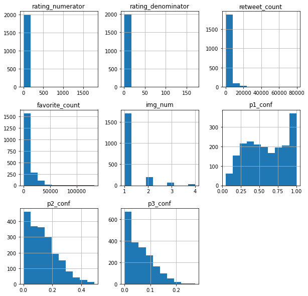

```python
master_df.hist(figsize=(10,10));
```

###### For the categorical column, `dog_stage`

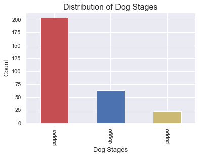

```python
stage = master_df['dog_stage'].value_counts().head(3)
colors = ['r', 'b', 'y']
stage.plot(kind='bar', color = colors)
plt.title('Distribution of Dog Stages', fontsize=16)
plt.xlabel('Dog Stages', fontsize=13)
plt.ylabel('Count', fontsize=13)
plt.show()
```

Of the 306 dogs with defined dog stages, **the dog stage, `pupper`, is the most popular** with more than 200 dogs (about 70%) listed as pupper, followed by `doggo` at about 21% and `puppo` at ~ 8%.

*Go to Table of Contents*

#### Data Used

The data used for each analysis and visualization is the wrangled datasets merged into a single file and saved as `twitter_archive_master.csv`

### References

- For updated exception error to gather data from API: *[Tweepy](https://docs.tweepy.org/en/stable/exceptions.html)* and *[TweepError](https://stackoverflow.com/questions/68412800/tweeperror-attribute-error-when-using-tweepy)*.
- Template for code used to read tweet_json.txt to a dataframe gotten from [Ademola Oladapo](https://alx-nd-c1.slack.com/archives/C03CRB0V6J2/p1657271483905439?thread_ts=1657271081.343879&cid=C03CRB0V6J2) -- Data Analyst - Session Lead on Slack.
- For extracting string(s) from a list used in extracting lower-case strings from the name column during wrangling, see [here](https://stackoverflow.com/questions/53935954/how-to-get-only-lowercase-strings-from-a-list-using-list-comprehension).

*Go to Table of Contents*